# ME613 - Análise de Regressão

## Introdução

## Introdução

Análise de regressão é uma metodologia estatística que utiliza a relação entre duas ou mais variáveis de maneira que uma variável pode ser predita pela(s) outra(s).

É uma metodologia amplamente utilizada em diversas áreas, pois é de relativamente fácil interpretação.

## Francis Galton e os dados sobre altura

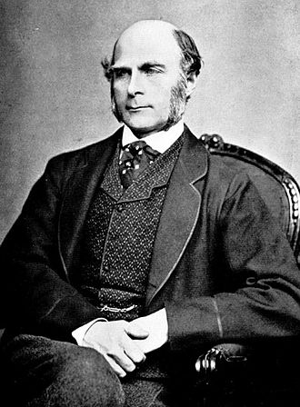

Galton inventou os conceitos de correlação e regressão.

> Em um de seus estudos, investigou a idéia de que filhos de pais altos eram altos, mas não tanto quanto seus pais. Filhos de pais mais baixos eram baixos, mas nem tanto quanto seus pais.

> Ele se referiu a isso como “regressão para a média”. Seus resultados foram publicados no artigo [Regression toward Mediocrity in Hereditary Stature](http://galton.org/essays/1880-1889/galton-1886-jaigi-regression-stature.pdf).

## Francis Galton e os dados sobre altura

O trabalho de Galton, publicado seu trabalho em 1886, ainda é relevante.

> Em 2009 pesquisadores compararam o modelo de Galton com modelos utilizando dados genômicos e o modelo de Galton se mostrou superior. Os resultados foram publicados no artigo [Predicting human height by Victorian and genomic methods](http://www.nature.com/ejhg/journal/v17/n8/full/ejhg20095a.html).

Considere que tenhamos interesse nas seguintes questões:

- Usar a altura dos pais para predizer a dos filhos.
- Encontrar uma maneira simples de explicar a relação entre a altura média dos pais e a altura média dos filhos.
- Investigar a variação na altura dos filhos que parece não estar relacionada com a altura dos pais (variação residual).
- Descobrir quais as suposições são necessárias para generalizar as descobertas realizadas com os dados em mãos para outros dados.
- Por que filhos de pais muito altos tendem a ser altos, mas nem tanto quanto seus pais.
- Por que filhos de pais muito baixos tendem a ser baixos, mas nem tanto quanto seus pais.

> Modelos de regressão podem nos ajudar a responder essas perguntas.

## Francis Galton e os dados sobre altura

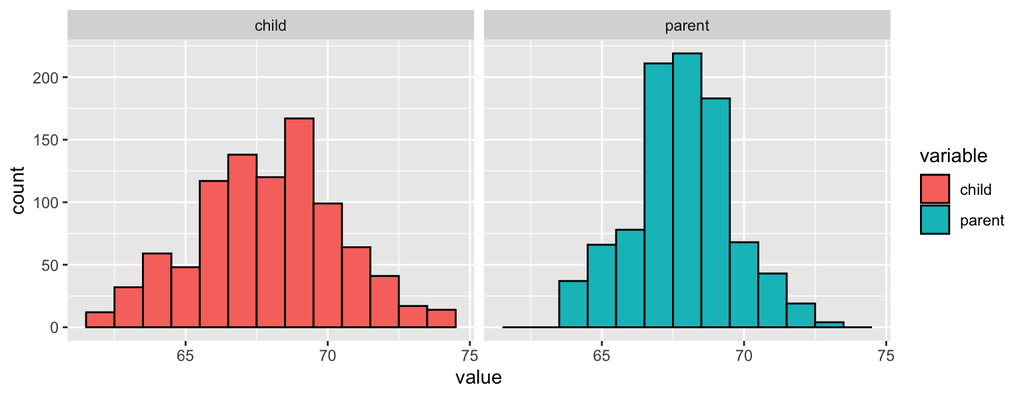

- Dados de 1885, usados por Galton.
- Observamos primeiramente as distribuições marginais: apenas dos pais, apenas dos filhos.
- Alturas das mulheres foram multiplicadas por 1.08

## Encontrando o centro via mínimos quadrados

Considerando apenas as alturas dos filhos:

- Se você fosse tentar advinhar um valor para a altura de um dos filhos, utilizando apenas o histograma/dados dos filhos, como você faria?
- Como descrever o “centro/meio”?
- Um definição: seja \(Y_i\) a altura do filho \(i\) para \(i = 1, \ldots, n = 928\), então definimos o centro como o valor de \(\mu\) que minimiza \[\sum_{i=1}^n (Y_i - \mu)^2\]
- É o centro de massa do histograma.
- Temos que \(\mu = \bar Y\) (demonstrar!)

## Encontrando o centro via mínimos quadrados usando RStudio

```r
library(UsingR); data(galton); library(reshape); long <- melt(galton)
library(manipulate)
myHist <- function(mu){
    mse <- mean((galton$child - mu)^2)
    g <- ggplot(galton, aes(x = child)) + geom_histogram(fill = "salmon",
                                                         colour = "black", binwidth=1)
    g <- g + geom_vline(xintercept = mu, size = 3)
    g <- g + ggtitle(paste("mu = ", mu, ", MSE = ", round(mse, 2), sep = ""))
    g
}
manipulate(myHist(mu), mu = slider(62, 74, step = 0.5))
```

## A estimativa por mínimos quadrados é a média

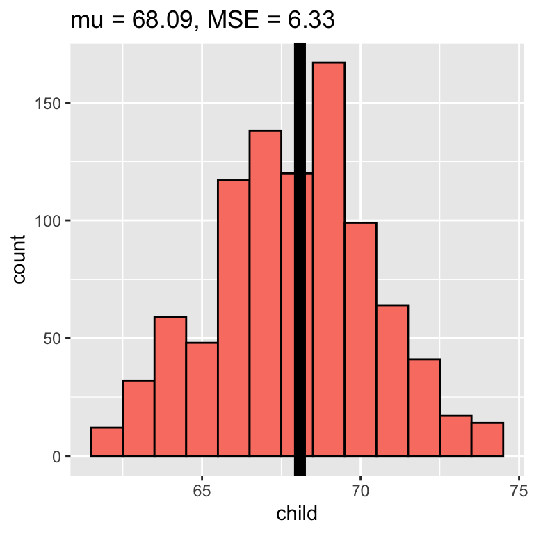

\(\bar{y}=68.09\)

## Matematicamente

\[\begin{eqnarray} \sum_{i=1}^n (Y_i - \mu)^2 & = & \sum_{i=1}^n (Y_i - \bar Y + \bar Y - \mu)^2 \\ & = & \sum_{i=1}^n (Y_i - \bar Y)^2 + 2 \sum_{i=1}^n (Y_i - \bar Y) (\bar Y - \mu) + \sum_{i=1}^n (\bar Y - \mu)^2 \\ & = & \sum_{i=1}^n (Y_i - \bar Y)^2 + 2 (\bar Y - \mu) \sum_{i=1}^n (Y_i - \bar Y) + \sum_{i=1}^n (\bar Y - \mu)^2 \\ & = & \sum_{i=1}^n (Y_i - \bar Y)^2 + 2 (\bar Y - \mu) (\sum_{i=1}^n Y_i - n \bar Y) + \sum_{i=1}^n (\bar Y - \mu)^2 \\ & = & \sum_{i=1}^n (Y_i - \bar Y)^2 + \sum_{i=1}^n (\bar Y - \mu)^2\\ & \geq & \sum_{i=1}^n (Y_i - \bar Y)^2 \end{eqnarray}\]

## Utilizando os dados dos pais

- Será que utilizando a informação dos pais conseguimos uma predição melhor para a altura do filho?
- Será que há alguma relação entre essas alturas? Como descobrir?

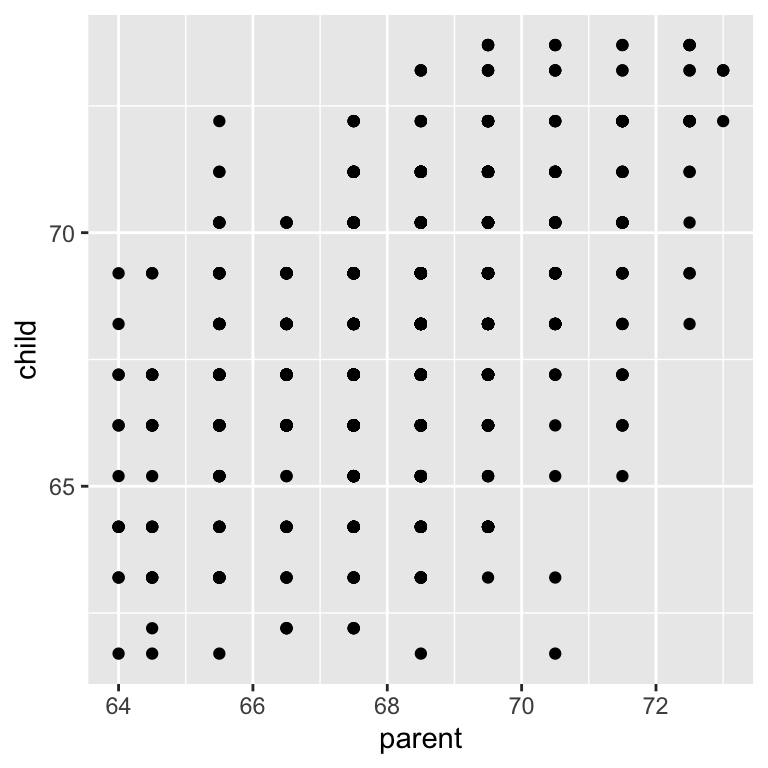

## Utilizando os dados dos pais

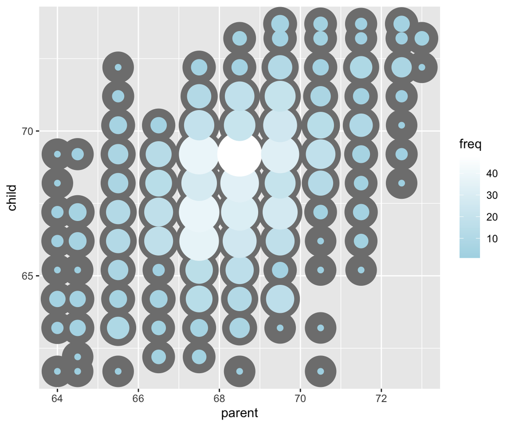

## Regressão pela origem

- Encontrar uma reta que melhor se ajusta aos pontos do gráfico.
- \(X_i\) é a altura média dos pais da criança \(i\) e \(Y_i\) é a altura da criança \(i\).
- \(Y_i=\alpha+X_i\beta+\varepsilon_i\), isto é \(\alpha+X_i\beta\) é a reta e \(\varepsilon\) um termo de erro.
- Precisamos encontrar o intercepto (\(\alpha\)) e o coeficiente angular (\(\beta\)) para definir a reta. Inicialmente, para simplificar, \(\alpha=0\) (reta passa pela origem).
- Procuramos \(\beta\) que minimiza

\[\sum_{i=1}^n (Y_i - X_i \beta)^2\]

- Estamos procurando uma reta, a partir da origem, que minimiza o quadrado das distâncias verticais dos pontos do gráfico até ela.

```r
myPlot <- function(beta){
  y <- galton$child - mean(galton$child)
  x <- galton$parent - mean(galton$parent)
  freqData <- as.data.frame(table(x, y))
  names(freqData) <- c("child", "parent", "freq")
  plot(
    as.numeric(as.vector(freqData$parent)),
    as.numeric(as.vector(freqData$child)),
    pch = 21, col = "black", bg = "lightblue",
    cex = .15 * freqData$freq,
    xlab = "parent",
    ylab = "child"
    )
  abline(0, beta, lwd = 3)
  points(0, 0, cex = 2, pch = 19)
  mse <- mean( (y - beta * x)^2 )
  title(paste("beta = ", beta, "mse = ", round(mse, 3)))
}
manipulate(myPlot(beta), beta = slider(0.6, 1.2, step = 0.02))
```

## Solução direta pelo R

```r
lm(I(child - mean(child))~ I(parent - mean(parent)) - 1, data = galton)
```

```
##
## Call:
## lm(formula = I(child - mean(child)) ~ I(parent - mean(parent)) -
##     1, data = galton)
##
## Coefficients:
## I(parent - mean(parent))
##                   0.6463
```

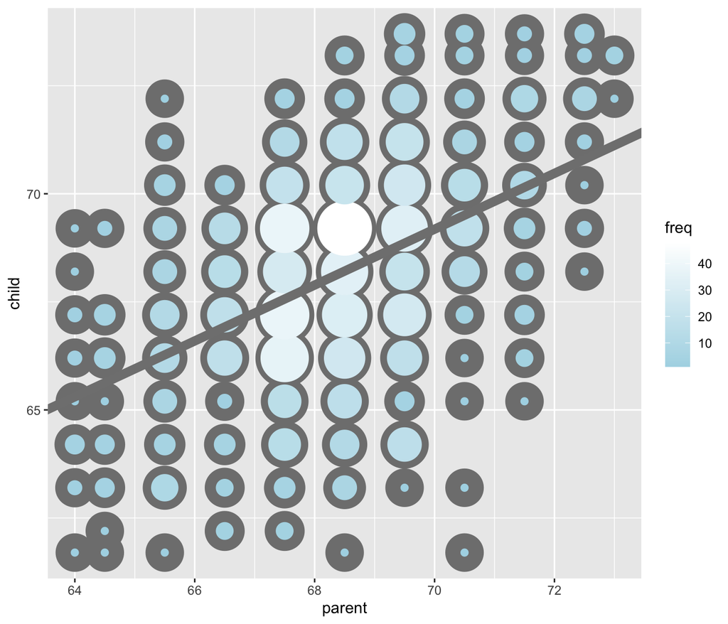

## Regressão Linear Simples

## Modelo de Regressão Linear Simples

Em muitas situações a relação entre duas variáveis pode ser descrita por uma reta.

> Podemos assumir que a reta de regressão da variável \(Y\) na variável \(X\) tem a forma \(\beta_0+\beta_1 X\).

> Desta maneira, consideramos o modelo:

\[Y_i=\beta_0+\beta_1X_i+\varepsilon_i\]

ou seja, para um dado \(X_i\), o valor correspondente de \(Y_i\) consiste no valor \(\beta_0+\beta_1X_i\) mais um termo \(\varepsilon_i\), que é o incremento indicando a distância de \(Y_i\) da reta \(\beta_0+\beta_1X_i\).

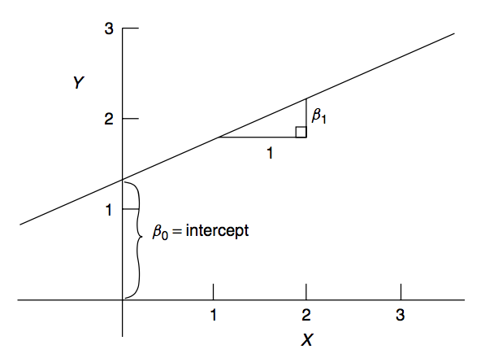

## Estimação por Mínimos Quadrados

\(\beta_0\), \(\beta_1\) e \(\varepsilon_i\) são desconhecidos.

\(\varepsilon_i\) depende da observação \(i\), mas \(\beta_0\) e \(\beta_1\) são constantes para todo \(i\), portanto mais simples de serem estimados.

Suponha que tenhamos \(n\) pares de observações: \((X_1,Y_1),(X_2,Y_2),\ldots,(X_n,Y_n)\). Equação do modelo de regressão linear:

\[Y_i=\beta_0+\beta_1X_i+\varepsilon_i\]

A soma dos desvios ao quadrado de cada observação \(Y_i\) até a reta \(\beta_0+\beta_1X_i\) é dada por:

\[S=\sum_{i=1}^n\varepsilon_i^2 = \sum_{i=1}^n (Y_i-\beta_0-\beta_1X_i)^2\]

## Estimação por Mínimos Quadrados

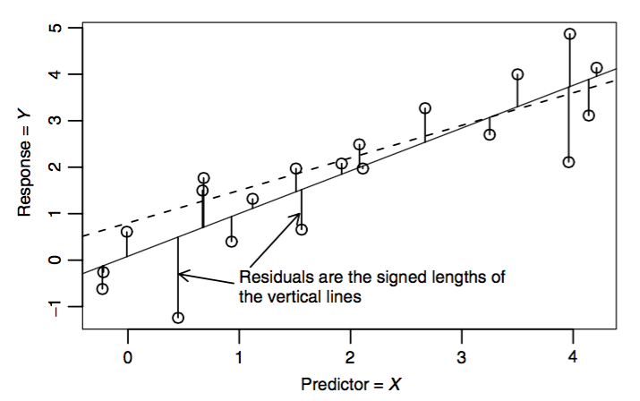

## Estimação por Mínimos Quadrados

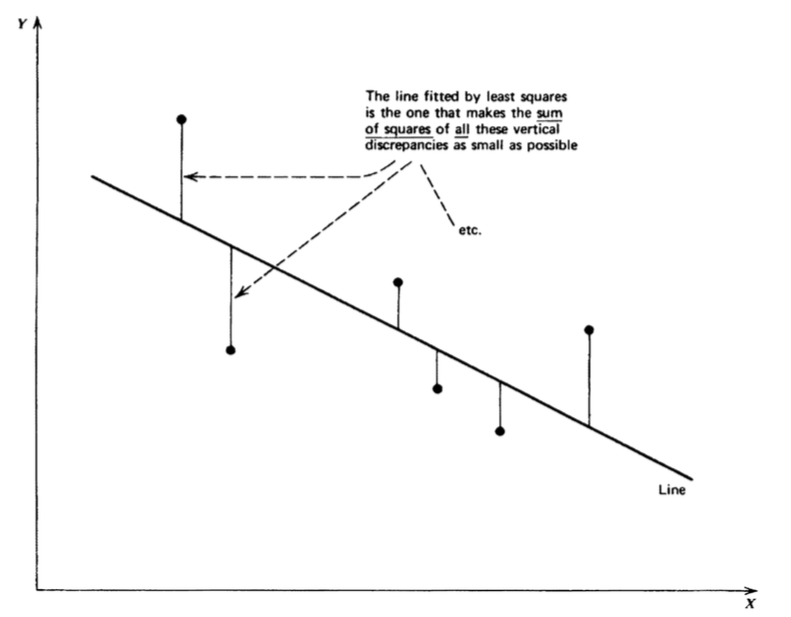

## Estimação por Mínimos Quadrados

Queremos encontrar \(\hat{\beta}_0\) e \(\hat{\beta}_1\) de tal forma que a reta resultante ao substituirmos esses valores no lugar de \(\beta_0\) e \(\beta_1\) minimiza a soma dos desvios ao quadrado.

\[\frac{\partial S}{\partial\beta_0}=-2\sum_{i=1}^n(Y_i-\beta_0-\beta_1X_i)\]

\[\frac{\partial S}{\partial\beta_1}=-2\sum_{i=1}^nX_i(Y_i-\beta_0-\beta_1X_i)\]

Igualamos cada equação acima a zero para encontrar \(\hat{\beta}_0\) e \(\hat{\beta}_1\) que minimizam \(S\).

## Estimação por Mínimos Quadrados

Equações normais:

\[\begin{eqnarray} \sum_{i=1}^n(Y_i-\hat{\beta}_0-\hat{\beta}_1X_i)&=&0\\ \sum_{i=1}^nX_i(Y_i-\hat{\beta}_0-\hat{\beta}_1X_i)&=&0 \end{eqnarray}\]

ou

\[\begin{eqnarray} \sum_{i=1}^n Y_i-n\hat{\beta}_0-\hat{\beta}_1\sum_{i=1}^nX_i&=&0\\ \sum_{i=1}^nX_iY_i-\hat{\beta}_0\sum_{i=1}^nX_i-\hat{\beta}_1\sum_{i=1}^nX_i^2&=&0 \end{eqnarray} \]

## Estimação por Mínimos Quadrados

\[\hat{\beta}_1=\frac{\sum_{i=1}^n(X_i-\bar{X})(Y_i-\bar{Y})}{\sum_{i=1}^n(X_i-\bar{X})^2}\]

\[\hat{\beta}_0=\bar{Y}-\hat{\beta}_1\bar{X}\]

Obtemos então a **equação de regressão estimada**:

\[\hat{Y}_i=\hat{E}(Y\mid X=X_i)=\hat{\beta}_0+\hat{\beta}_1X_i=\bar{Y}+\hat{\beta}_1(X_i-\bar{X})\]

([vídeo](https://www.youtube.com/watch?v=COVQX8WZVA8&index=8&list=PLpl-gQkQivXjqHAJd2t-J_One_fYE55tC))

## Dados de Galton - estimação por mínimos quadrados

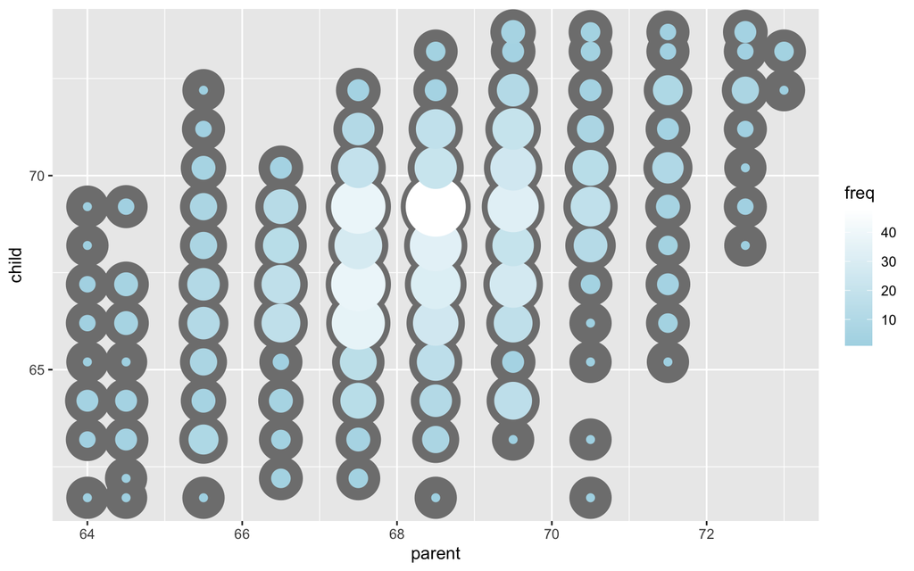

## Usando o R

O R tem a função `lm` para ajuste de regressão linear.

```r
y <- galton$child
x <- galton$parent
beta1 <- cor(y, x) *  sd(y) / sd(x)
beta0 <- mean(y) - beta1 * mean(x)
rbind(c(beta0, beta1), coef(lm(y ~ x)))
```

```
##      (Intercept)         x
## [1,]    23.94153 0.6462906
## [2,]    23.94153 0.6462906
```

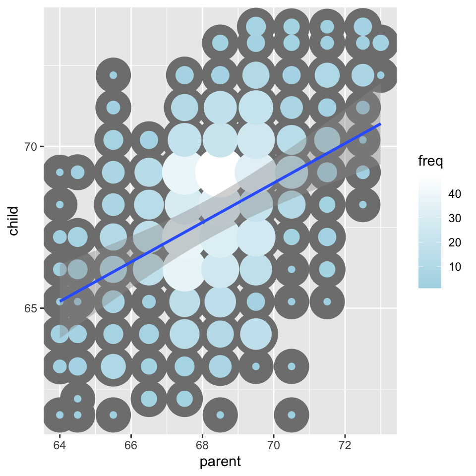

\(\hat{\beta}_0=23.9415302\) e \(\hat{\beta}_1=0.6462906\).

## Propriedades dos estimadores

## Suposições do modelo de regressão linear simples

Nenhuma suposição sobre distribuição de probabilidade foi feita até o momento.

A partir de agora iremos assumir:

1. \[Y_i=\beta_0+\beta_1X_i+\varepsilon_i\quad i=1,2,\ldots,n\]
2. \(\varepsilon_i\) uma v.a. em que \(E(\varepsilon_i)=0\) e \(Var(\varepsilon_i)=\sigma^2\) desconhecida, para \(i=1,2,\ldots,n\).
3. \(\varepsilon_i\) e \(\varepsilon_j\) são não-correlacionados para \(i\neq j\), portanto \(Cov(\varepsilon_i,\varepsilon_j)=0\) para \(i\neq j\).

## Propriedades de \(Y_i\)

O valor esperado para a resposta \(Y_i\), fixando \(X_i\) é:

\[\begin{eqnarray} E(Y_i) & = & E(\beta_0+\beta_1 X_i+\varepsilon_i)\\ &=&\beta_0+\beta_1X_i+E(\varepsilon_i)\\ &=&\beta_0+\beta_1X_i \end{eqnarray} \]

> A variância para a resposta \(Y_i\), fixando \(X_i\) é:

\[\begin{eqnarray} Var(Y_i) & = & Var(\beta_0+\beta_1 X_i+\varepsilon_i)\\ &=&Var(\varepsilon_i)=\sigma^2 \end{eqnarray} \]

> A resposta \(Y_i\) vem de uma distribuição de probabilidade com \(E(Y_i)=\beta_0+\beta_1X_i\) (**função de regressão**) e \(Var(Y_i)=\sigma^2\). A resposta, \(Y_i\) está acima ou abaixo da função de regressão por um termo de erro \(\varepsilon_i\).

## Propriedades de \(\hat{\beta}_1\)

\[\begin{eqnarray} \hat{\beta}_1 &=& \frac{\sum_{i=1}^n(X_i-\bar{X})(Y_i-\bar{Y})}{\sum_{i=1}^n(X_i-\bar{X})^2}\\ &=&\frac{1}{\sum_{i=1}^n(X_i-\bar{X})^2}\left(\sum_{i=1}^n(X_i-\bar{X})Y_i-\sum_{i=1}^n(X_i-\bar{X})\bar{Y} \right)\\ &=&\frac{1}{\sum_{i=1}^n(X_i-\bar{X})^2}\left(\sum_{i=1}^n(X_i-\bar{X})Y_i-\underbrace{\sum_{i=1}^n(X_i-\bar{X})}_{0}\bar{Y} \right)\\ &=& \frac{\sum_{i=1}^n\color{red}{(X_i-\bar{X})}Y_i}{\color{red}{\sum_{i=1}^n(X_i-\bar{X})^2}}=\sum_{i=1}^n\color{red}{a_i}Y_i \end{eqnarray}\]

## Propriedades de \(\hat{\beta}_1\)

\[\begin{eqnarray} E(\hat{\beta}_1) &=& E\left(\sum_{i=1}^na_iY_i\right)=\sum_{i=1}^na_iE(Y_i)\\ &=&\sum_{i=1}^na_i(\beta_0+\beta_1X_i)=\beta_0\sum_{i=1}^na_i+\beta_1\sum_{i=1}^na_iX_i\\ &=&\beta_0\underbrace{\sum_{i=1}^na_i}_0+\beta_1\underbrace{\sum_{i=1}^na_iX_i}_1\\ &=&\beta_1 \end{eqnarray}\]

## Propriedades de \(\hat{\beta}_1\)

\[\begin{eqnarray} Var(\hat{\beta}_1) &=& Var\left(\sum_{i=1}^n a_iY_i \right)\\ &=&\sum_{i=1}^na_i^2Var(Y_i)=\sum_{i=1}^na_i^2\sigma^2\\ &=&\sigma^2\sum_{i=1}^na_i^2\\ &=&\frac{\sigma^2}{\sum_{i=1}^n(X_i-\bar{X})^2} \end{eqnarray}\]

## Precisão de \(\hat{\beta}_0\)

**Mostre\(^1\)** que

\[Var(\hat{\beta}_0) = \sigma^2\left (\frac{1}{n} + \frac{\bar{X}^2}{\sum_{i=1}^n(X_i-\bar{X})^2} \right)\]

**Mostre\(^2\)** que

\[Cov(\hat{\beta}_0,\hat{\beta}_1)= -\sigma^2\frac{\bar{X}}{\sum_{i=1}^n(X_i-\bar{X})^2}\]

**Mostre\(^3\)** que \(E(\hat{\beta}_0)=\beta_0\).

## Propriedades dos estimadores

Não importa a distribuição de probabilidade de \(\varepsilon_i\) (anteriormente definimos apenas os momentos nas suposições do modelo), o método de mínimos quadrados fornece estimadores não-viesados para \(\beta_0\) e \(\beta_1\).

## Análise de Variância

Quanto da variabilidade dos dados foi capturada pela reta ajustada?

> \[Y_i-\hat{Y}_i=Y_i-\bar{Y}-(\hat{Y}_i-\bar{Y})\]

> O resíduo \(e_i=Y_i-\hat{Y}_i\) é a diferença entre:
1. o valor observado \(Y_i\) e a média \(\bar{Y}\)
2. o valor ajustado \(\hat{Y}_i\) e a média \(\bar{\hat{Y}}=\bar{Y}\).

## Análise de Variância

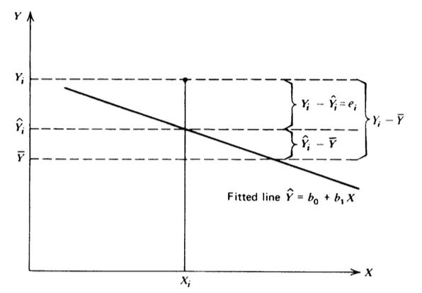

## Análise de Variância

\[(Y_i-\bar{Y})=(\hat{Y}_i-\bar{Y})+(Y_i-\hat{Y}_i)\]

**Mostre\(^4\)** que elevando ambos os lados da equação ao quadrado e somando, temos:

\[\sum_{i=1}^n(Y_i-\bar{Y})^2=\sum_{i=1}^n(\hat{Y}_i-\bar{Y})^2+\sum_{i=1}^n(Y_i-\hat{Y}_i)^2\]

## Análise de Variância

\[ \underbrace{\sum_{i=1}^n(Y_i-\bar{Y})^2}_{SQT}=\underbrace{\sum_{i=1}^n(\hat{Y}_i-\bar{Y})^2}_{SQReg} +\underbrace{\sum_{i=1}^n(Y_i-\hat{Y}_i)^2}_{SQE}\]

- **SQT** é a soma dos quadrados total (ajustada), representa a variação total de \(Y\) em torno de sua média.
- **SQReg** é a soma de quadrados da regressão, representa a variação total de \(\hat{Y}\) em torno de sua média.
- **SQE** é a soma dos quadrados do erro, representa a variação de \(Y\) em torno da reta ajustada.

## Análise de Variância

Queremos avaliar quão bom é nosso modelo de regressão.

> Caso ideal: todas as observações se ajustam perfeitamente à reta. Neste caso: \(SQE=\sum_{i=1}^n(Y_i-\hat{Y}_i)^2=0\).

> Para avaliar o modelo: observar quanto da \(SQT\) está contida em \(SQReg\) e quanto está na \(SQE\).

> Podemos utilizar para avaliar o modelo: \[R^2=\frac{\sum_{i=1}^n(\hat{Y}_i-\bar{Y})^2}{\sum_{i=1}^n(Y_i-\bar{Y})^2}\]

conhecido como **coeficiente de determinação**, que é a proporção da variabilidade total explicada pelo modelo de regressão ajustado.

Cuidado!

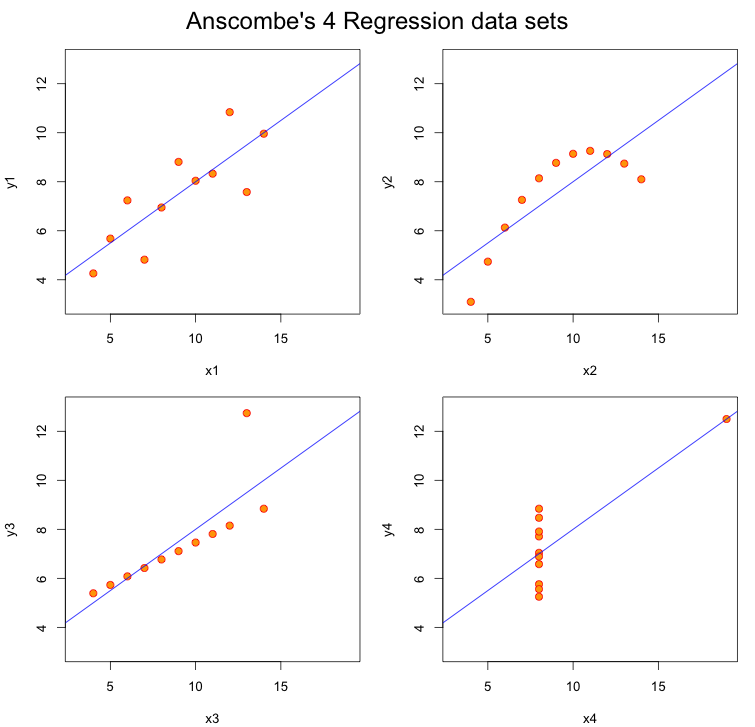

\(R^2=0.66\) em todos os exemplos acima.

## Análise de Variância

| Fonte de Variação | gl | SQ |
| --- | --- | --- |
| Regressão | \(1\) | \(SQReg=\sum_{i=1}^n(\hat{Y}_i-\bar{Y})^2\) |
| Erro | \(n-2\) | \(SQE=\sum_{i=1}^n(Y_i-\hat{Y})^2\) |
| Total (ajustada) | \(n-1\) | \(SQT=\sum_{i=1}^n(Y_i-\bar{Y})^2\) |

## Análise de Variância

Utilizamos a tabela de análise de variância para comparar dois modelos:

1. \(Y_i=\beta_0+\varepsilon_i\quad i=1,2,\ldots,n\)
2. \(Y_i=\beta_0+\beta_1X_i+\varepsilon_i\quad i=1,2,\ldots,n\)

Para o modelo 1, vimos que \(\hat{\beta}_0=\bar{Y}\), portanto a soma dos quadrados dos resíduos deste modelo é dada por:

\[\sum_{i=1}^n(Y_i-\hat{\beta}_0)^2=\sum_{i=1}^n(Y_i-\bar{Y})^2\]

Para o modelo 2, a soma dos quadrados dos resíduos é dada por:

\[\sum_{i=1}^n(Y_i-\hat{Y}_i)^2\]$

## Análise de Variância

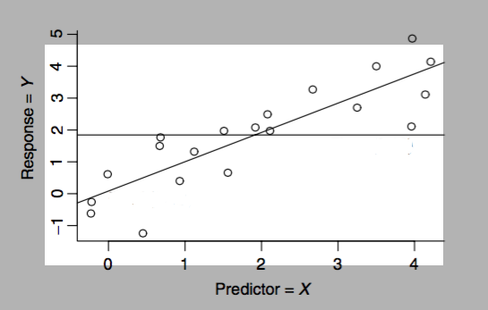

Comparando modelo 1 (reta horizontal, \(X\) e \(Y\) não apresentam relação linear) com o modelo 2.

## \(\sigma^2\) é desconhecido

Como \(\sigma^2\) desconhecido, \(Var(\hat{\beta}_0)\), \(Var(\hat{\beta}_1)\) e \(Cov(\hat{\beta}_0,\hat{\beta}_1)\) também são desconhecidos.

Um estimador não viesado para \(\sigma^ 2\) é:

\[s^2=QME=\frac{SQE}{n-2}=\frac{\sum_{i=1}^n(Y_i-\hat{Y}_i)^2}{n-2}\]

## Leitura

- Applied Linear Statistical Models: Seções 1.1 a 1.7, 2.1, 2.2.
- Caffo - [Regression Models for Data Science in R](https://leanpub.com/regmods): Introduction, Notation, Ordinary least squares, Regression to the mean, Statistical linear regression models, Residuals.
- Draper & Smith - [Applied Regression Analysis](http://onlinelibrary.wiley.com/book/10.1002/9781118625590): Capítulo 0, 1.1 a 1.3.
- Weisberg - Applied Linear Regression: Capítulo 1, 2.1 a 2.5, 2.7.

[figure not shown]